# Aluguel de bicicleta nos Estados Unidos

# 2 Transformação de Carga

Na transformação de carga iremos realizar a normalização das variáveis numéricas, transformando toda as coluna em uma mesma escala, para que possamos na hora de criar o modelo preditivo, possamos observar um nível de acúrária melhor.

Iremos também criar novas variáveis, para melhor entendimento do conjuntos de dados, afim de evitar possíveis erros em nosso conjuntos. Criaremos a coluna (“isWorking” - dias úteis, “monthCount” - mês e “dayWeek” - dia de semana).

```r
cols <- c("dteday", "mnth", "hr", "holiday",
          "workingday", "weathersit", "temp",
          "hum", "windspeed", "cnt")

# Criando um subset dos dados
bikes <- bikes[,cols]

# Transformar o objeto de data
bikes$dteday <- char.toPOSIXct(bikes)

# Esta linha acima gera dois valores NA
# Esta linha abaixo corrige

bikes <- na.omit(bikes)

# Normalizar as variaveis preditoras numericas

cols <- c('temp', 'hum', 'windspeed')
bikes[,cols] <- scale(bikes[,cols])

str(bikes)
```

```
## 'data.frame':    10342 obs. of  10 variables:
##  $ dteday    : POSIXct, format: "2011-01-01 14:00:00" "2011-01-01 15:00:00" ...
##  $ mnth      : int  1 1 1 1 1 1 1 1 1 1 ...
##  $ hr        : int  14 15 8 17 18 19 8 17 18 19 ...
##  $ holiday   : int  0 0 0 0 0 0 0 0 0 0 ...
##  $ workingday: int  0 0 1 1 1 1 1 1 1 1 ...
##  $ weathersit: int  2 2 1 1 1 1 1 1 1 1 ...
##  $ temp      : num  -0.542 -0.653 -2.317 -1.762 -1.762 ...
##  $ hum       : num  0.783 1.056 -0.417 -1.509 -1.399 ...
##  $ windspeed : num  0.682 0.805 0.682 0.193 -0.787 ...
##  $ cnt       : int  106 110 154 157 157 110 179 212 182 112 ...
##  - attr(*, "na.action")= 'omit' Named int [1:2] 3581 9289
##   ..- attr(*, "names")= chr [1:2] "3581" "9289"
```

```r
rbind(head(bikes), tail(bikes))
```

|  | dteday | mnth | hr | holiday | workingday | weathersit | temp | hum | windspeed | cnt |
| --- | --- | --- | --- | --- | --- | --- | --- | --- | --- | --- |
| 1 | 2011-01-01 14:00:00 | 1 | 14 | 0 | 0 | 2 | -0.5416351 | 0.7833175 | 0.6824444 | 106 |
| 2 | 2011-01-01 15:00:00 | 1 | 15 | 0 | 0 | 2 | -0.6525774 | 1.0561580 | 0.8047050 | 110 |
| 3 | 2011-01-03 08:00:00 | 1 | 8 | 0 | 1 | 1 | -2.3167126 | -0.4171805 | 0.6824444 | 154 |
| 4 | 2011-01-03 17:00:00 | 1 | 17 | 0 | 1 | 1 | -1.7620009 | -1.5085424 | 0.1925812 | 157 |
| 5 | 2011-01-03 18:00:00 | 1 | 18 | 0 | 1 | 1 | -1.7620009 | -1.3994062 | -0.7871450 | 157 |
| 6 | 2011-01-03 19:00:00 | 1 | 19 | 0 | 1 | 1 | -1.9838856 | -0.5808848 | -1.6446106 | 110 |
| 10339 | 2012-12-31 14:00:00 | 12 | 14 | 0 | 1 | 2 | -1.5401162 | -0.6900210 | 0.1925812 | 247 |
| 10340 | 2012-12-31 15:00:00 | 12 | 15 | 0 | 1 | 2 | -1.5401162 | -0.6900210 | -0.5426237 | 315 |
| 10341 | 2012-12-31 16:00:00 | 12 | 16 | 0 | 1 | 2 | -1.6510585 | -0.5263167 | -0.0527606 | 214 |
| 10342 | 2012-12-31 17:00:00 | 12 | 17 | 0 | 1 | 2 | -1.6510585 | -0.5263167 | -0.9094056 | 164 |

[output cut: 2 more lines]

```r
# Criar uma nova variável para indicar dia da semana (workday)
bikes$isWorking <- ifelse(bikes$workingday & !bikes$holiday, 1, 0)

# Adicionar uma coluna com a quantidade de meses, o que vai ajudar a criar o modelo
month.count <- function(inFrame){
  Dteday <- strftime(inFrame$dteday, format = "%Y-%m-%dT%H:%M:%S")
  yearCount <- as.numeric(unlist(lapply(strsplit(
    Dteday, "-"),
    function(x){x[1]}))) - 2011
  inFrame$monthCount <- 12 * yearCount + inFrame$mnth
  inFrame
}

bikes <- month.count(bikes)

# Criar um fator ordenado para o dia da semana, comecando por segunda-feira
bikes$dayWeek <- as.factor(weekdays(bikes$dteday))

head(bikes)
```

|  | dteday | mnth | hr | holiday | workingday | weathersit | temp | hum | windspeed | cnt | isWorking | monthCount | dayWeek |
| --- | --- | --- | --- | --- | --- | --- | --- | --- | --- | --- | --- | --- | --- |
| 1 | 2011-01-01 14:00:00 | 1 | 14 | 0 | 0 | 2 | -0.5416351 | 0.7833175 | 0.6824444 | 106 | 0 | 1 | sábado |
| 2 | 2011-01-01 15:00:00 | 1 | 15 | 0 | 0 | 2 | -0.6525774 | 1.0561580 | 0.8047050 | 110 | 0 | 1 | sábado |
| 3 | 2011-01-03 08:00:00 | 1 | 8 | 0 | 1 | 1 | -2.3167126 | -0.4171805 | 0.6824444 | 154 | 1 | 1 | segunda-feira |
| 4 | 2011-01-03 17:00:00 | 1 | 17 | 0 | 1 | 1 | -1.7620009 | -1.5085424 | 0.1925812 | 157 | 1 | 1 | segunda-feira |
| 5 | 2011-01-03 18:00:00 | 1 | 18 | 0 | 1 | 1 | -1.7620009 | -1.3994062 | -0.7871450 | 157 | 1 | 1 | segunda-feira |
| 6 | 2011-01-03 19:00:00 | 1 | 19 | 0 | 1 | 1 | -1.9838856 | -0.5808848 | -1.6446106 | 110 | 1 | 1 | segunda-feira |

Podemos observar que na tabela acima que na coluna “dayWeek” está recebendo os dias da semana: de segunda-feira à domingo.

A tabela abaixo a coluna “dayWeek” agora os dias da semana devem estar como valores numéricos.

```r
bikes$dayWeek <- as.numeric(ordered(bikes$dayWeek,
                                    levels = c("segunda-feira",
                                               "terça-feira",
                                               "quarta-feira",
                                               "quinta-feira",
                                               "sexta-feira",
                                               "sábado",
                                               "domingo")))


head(bikes)
```

|  | dteday | mnth | hr | holiday | workingday | weathersit | temp | hum | windspeed | cnt | isWorking | monthCount | dayWeek |
| --- | --- | --- | --- | --- | --- | --- | --- | --- | --- | --- | --- | --- | --- |
| 1 | 2011-01-01 14:00:00 | 1 | 14 | 0 | 0 | 2 | -0.5416351 | 0.7833175 | 0.6824444 | 106 | 0 | 1 | 6 |
| 2 | 2011-01-01 15:00:00 | 1 | 15 | 0 | 0 | 2 | -0.6525774 | 1.0561580 | 0.8047050 | 110 | 0 | 1 | 6 |
| 3 | 2011-01-03 08:00:00 | 1 | 8 | 0 | 1 | 1 | -2.3167126 | -0.4171805 | 0.6824444 | 154 | 1 | 1 | 1 |
| 4 | 2011-01-03 17:00:00 | 1 | 17 | 0 | 1 | 1 | -1.7620009 | -1.5085424 | 0.1925812 | 157 | 1 | 1 | 1 |
| 5 | 2011-01-03 18:00:00 | 1 | 18 | 0 | 1 | 1 | -1.7620009 | -1.3994062 | -0.7871450 | 157 | 1 | 1 | 1 |
| 6 | 2011-01-03 19:00:00 | 1 | 19 | 0 | 1 | 1 | -1.9838856 | -0.5808848 | -1.6446106 | 110 | 1 | 1 | 1 |

# 3 Engenharia de Atributos

Adiciona uma variável com valores únicos para o horário do dia em dias de semana e dias de fim de semana. Com isso diferenciamos as horas dos dias de semana, das horas em dias de fim de semana

```r
bikes$workTime <- ifelse(bikes$isWorking, bikes$hr, bikes$hr + 24)

# Transforma os valores de hora na madrugada, quando a demanda por bibicletas é praticamente nula
bikes$xformHr <- ifelse(bikes$hr > 4, bikes$hr - 5, bikes$hr + 19)

# Adiciona uma variável com valores únicos para o horário do dia para dias de semana e dias de fim de semana
# Considerando horas da madrugada
bikes$xformWorkHr <- ifelse(bikes$isWorking, bikes$xformHr, bikes$xformHr + 24)

str(bikes)
```

```
## 'data.frame':    10342 obs. of  16 variables:
##  $ dteday     : POSIXct, format: "2011-01-01 14:00:00" "2011-01-01 15:00:00" ...
##  $ mnth       : int  1 1 1 1 1 1 1 1 1 1 ...
##  $ hr         : int  14 15 8 17 18 19 8 17 18 19 ...
##  $ holiday    : int  0 0 0 0 0 0 0 0 0 0 ...
##  $ workingday : int  0 0 1 1 1 1 1 1 1 1 ...
##  $ weathersit : int  2 2 1 1 1 1 1 1 1 1 ...
##  $ temp       : num  -0.542 -0.653 -2.317 -1.762 -1.762 ...
##  $ hum        : num  0.783 1.056 -0.417 -1.509 -1.399 ...
##  $ windspeed  : num  0.682 0.805 0.682 0.193 -0.787 ...
##  $ cnt        : int  106 110 154 157 157 110 179 212 182 112 ...
##  $ isWorking  : num  0 0 1 1 1 1 1 1 1 1 ...
##  $ monthCount : num  1 1 1 1 1 1 1 1 1 1 ...
##  $ dayWeek    : num  6 6 1 1 1 1 2 2 2 2 ...
##  $ workTime   : num  38 39 8 17 18 19 8 17 18 19 ...
##  $ xformHr    : num  9 10 3 12 13 14 3 12 13 14 ...
##  $ xformWorkHr: num  33 34 3 12 13 14 3 12 13 14 ...
##  - attr(*, "na.action")= 'omit' Named int [1:2] 3581 9289
##   ..- attr(*, "names")= chr [1:2] "3581" "9289"
```

# 4 Análise de Correlação

Existe diversas técnicas para a análise de correlação entre as variáveis de nosso conjunto de dados. Em nosso modelo utilizaremos apenas duas:

- Pearson - coeficiente usado para medir o grau de relacionamento entre duas variáveis com relação linear;
- Spearman - teste não paramétrico, para medir o grau de relacionamento entre duas variaveis;

```r
cols <- c("mnth", "hr", "holiday", "workingday",
          "weathersit", "temp", "hum", "windspeed",
          "isWorking", "monthCount", "dayWeek",
          "workTime", "xformHr", "cnt")

# Vetor com os métodos de correlação

metodos <- c('pearson','spearman')

# Aplicando os métodos de correlação com a função cor()
cors <- lapply(metodos, function(method)
  (cor(bikes[,cols], method = method)))


head(cors)
```

```
## [[1]]
##                    mnth            hr      holiday    workingday  weathersit
## mnth        1.000000000 -0.0136042973  0.008793902 -0.0138388321  0.05840581
## hr         -0.013604297  1.0000000000 -0.005520887 -0.0006323913 -0.06736674
## holiday     0.008793902 -0.0055208870  1.000000000 -0.2425512192 -0.01835272
## workingday -0.013838832 -0.0006323913 -0.242551219  1.0000000000  0.04953479
## weathersit  0.058405813 -0.0673667444 -0.018352723  0.0495347916  1.00000000
## temp        0.064922430  0.0980559021  0.008323454 -0.0107187615 -0.10799126
## hum         0.169468456 -0.1618604473 -0.009470555  0.0342820187  0.43078518
## windspeed  -0.138354012  0.0407698801  0.009087200 -0.0117451965 -0.02761308
## isWorking  -0.013838832 -0.0006323913 -0.242551219  1.0000000000  0.04953479
## monthCount  0.402902865 -0.0183907785  0.012936999 -0.0144820763  0.03331750
## dayWeek     0.008096668  0.0057470548 -0.168587689 -0.6999169949 -0.05072788
## workTime    0.006903870  0.4174590932  0.218103726 -0.9089595324 -0.07309621
## xformHr     0.006098419  0.8160565174  0.001099527 -0.1151723378 -0.07917747
## cnt         0.072404459  0.0504996750 -0.010775456 -0.0178389461 -0.11363010
##                    temp          hum     windspeed     isWorking   monthCount
## mnth        0.064922430  0.169468456 -0.1383540123 -0.0138388321  0.402902865
## hr          0.098055902 -0.161860447  0.0407698801 -0.0006323913 -0.018390779
## holiday     0.008323454 -0.009470555  0.0090871999 -0.2425512192  0.012936999
## workingday -0.010718762  0.034282019 -0.0117451965  1.0000000000 -0.014482076
## weathersit -0.107991263  0.430785180 -0.0276130822  0.0495347916  0.033317501
## temp        1.000000000 -0.099110979 -0.0262672773 -0.0107187615 -0.032336350
## hum        -0.099110979  1.000000000 -0.2708755225  0.0342820187  0.019952516
## windspeed  -0.026267277 -0.270875522  1.0000000000 -0.0117451965 -0.074350779
## isWorking  -0.010718762  0.034282019 -0.0117451965  1.0000000000 -0.014482076
## monthCount -0.032336350  0.019952516 -0.0743507788 -0.0144820763  1.000000000
## dayWeek    -0.003146259 -0.053534426  0.0054068644 -0.6999169949  0.011405683
## workTime    0.050618075 -0.098629032  0.0276691407 -0.9089595324  0.005492974
## xformHr     0.109501457 -0.111091068 -0.0006654943 -0.1151723378  0.018037934
## cnt         0.271030746 -0.173727633  0.0278603203 -0.0178389461  0.300181501
##                 dayWeek     workTime       xformHr         cnt
## mnth        0.008096668  0.006903870  0.0060984187  0.07240446
## hr          0.005747055  0.417459093  0.8160565174  0.05049967
## holiday    -0.168587689  0.218103726  0.0010995270 -0.01077546
## workingday -0.699916995 -0.908959532 -0.1151723378 -0.01783895
## weathersit -0.050727878 -0.073096210 -0.0791774726 -0.11363010
## temp       -0.003146259  0.050618075  0.1095014572  0.27103075
## hum        -0.053534426 -0.098629032 -0.1110910680 -0.17372763
## windspeed   0.005406864  0.027669141 -0.0006654943  0.02786032
```

[output cut: 38 more lines]

```
##                 dayWeek     workTime       xformHr           cnt
## mnth        0.007751764  0.005768616  3.588295e-03  0.0709785050
## hr          0.024715511  0.611634311  9.066142e-01  0.0337063517
## holiday    -0.168111320  0.187554495 -4.852017e-05 -0.0009114978
## workingday -0.698787618 -0.787363909 -1.047542e-01 -0.0395310066
## weathersit -0.054903746 -0.104824215 -9.344981e-02 -0.1135697367
## temp       -0.008090398  0.065124023  9.907618e-02  0.2965684666
## hum        -0.055440865 -0.120032441 -1.036552e-01 -0.1828723968
## windspeed   0.008845523  0.030861247 -1.651065e-03  0.0387257114
## isWorking  -0.698787618 -0.787363909 -1.047542e-01 -0.0395310066
## monthCount  0.011940045  0.008132094  1.461216e-02  0.2817192592
## dayWeek     1.000000000  0.555704931  8.814110e-02  0.0402850454
## workTime    0.555704931  1.000000000  6.468276e-01  0.0520637898
## xformHr     0.088141100  0.646827621  1.000000e+00 -0.0389455295
## cnt         0.040285045  0.052063790 -3.894553e-02  1.0000000000
```

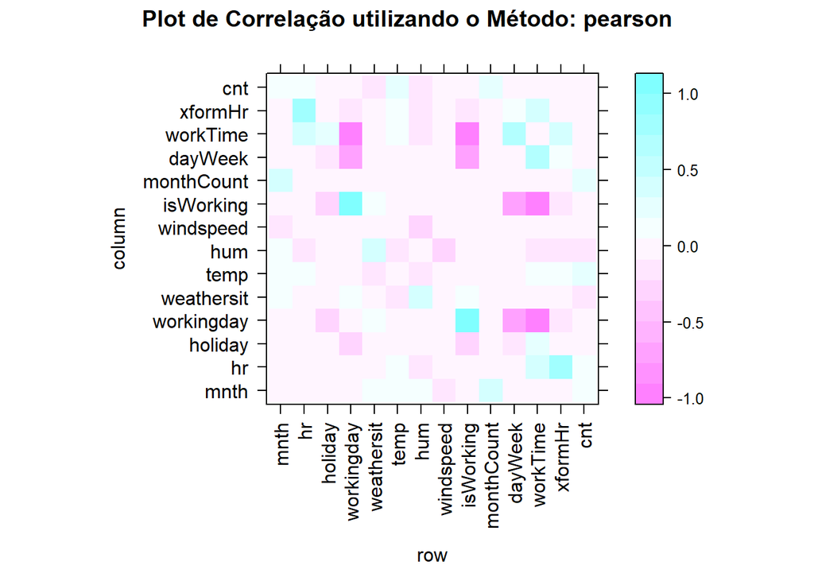

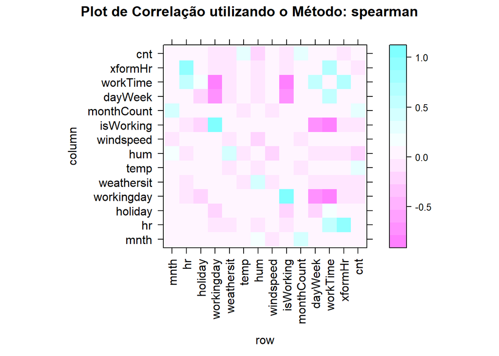

```r
# Preprando o plot
require(lattice)

plot.cors <- function(x, labs){
  diag(x) <- 0.0
  plot( levelplot(x,
                  main = paste("Plot de Correlação utilizando o Método:", labs),
                  scales = list(x = list(rot = 90), cex = 1.0)) )
}

# Mapa de Correlação
Map(plot.cors, cors, metodos)
```

# 5 Análise de Serie Temporal

Neste momente, após a exploraração de nosso conjunto de dados, será iniciado o estudo de “series temporis” em nosso conjuntos de dados. Será anlisado a demanda de bicicletas ao longo do tempo constuindo um time series plot para alguns determinados horários em dias úteis e dias de fim de semana, para que possamos começar a identificar relações e período de alta e baixa demanda de bicicletas.

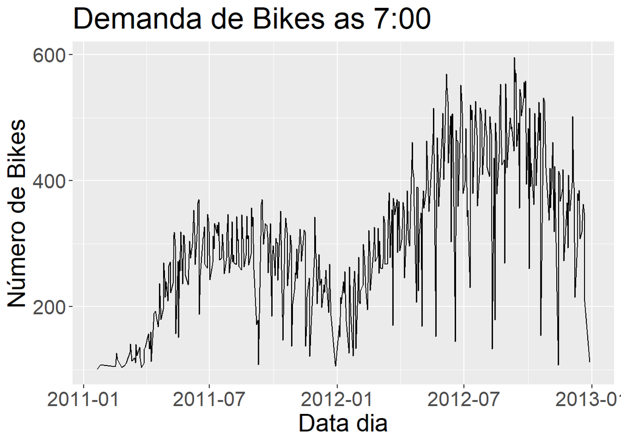

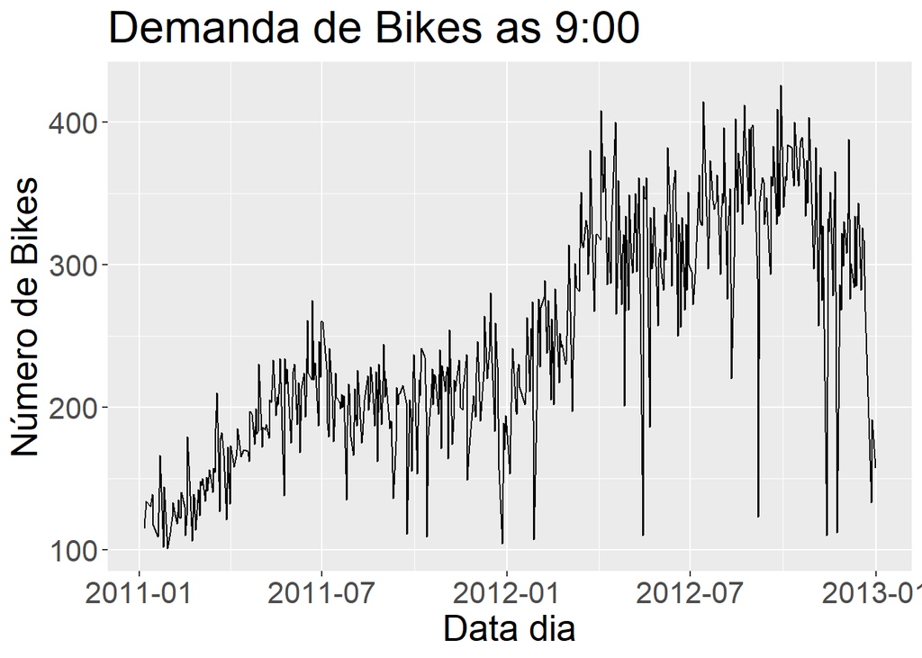

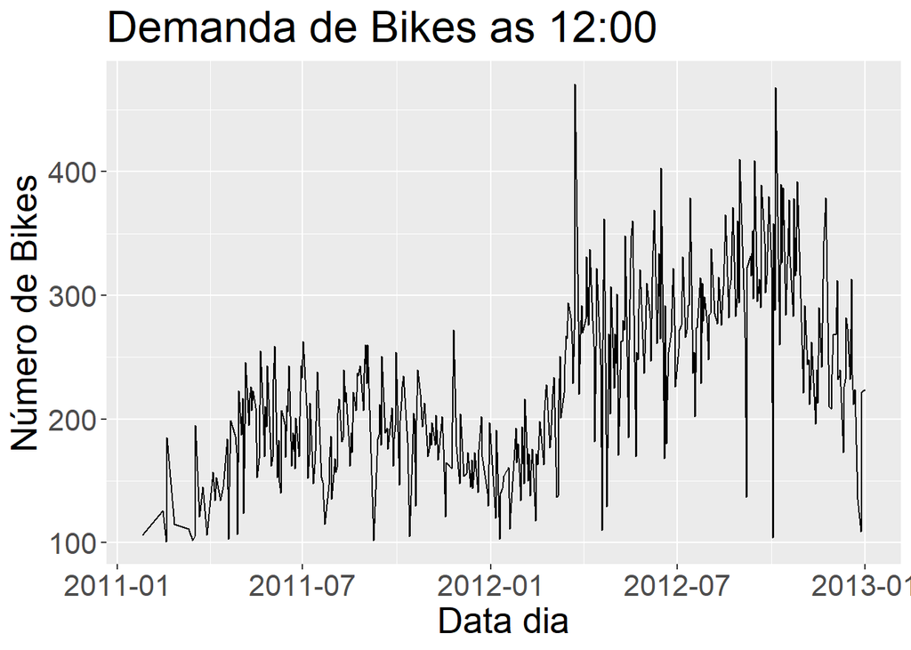

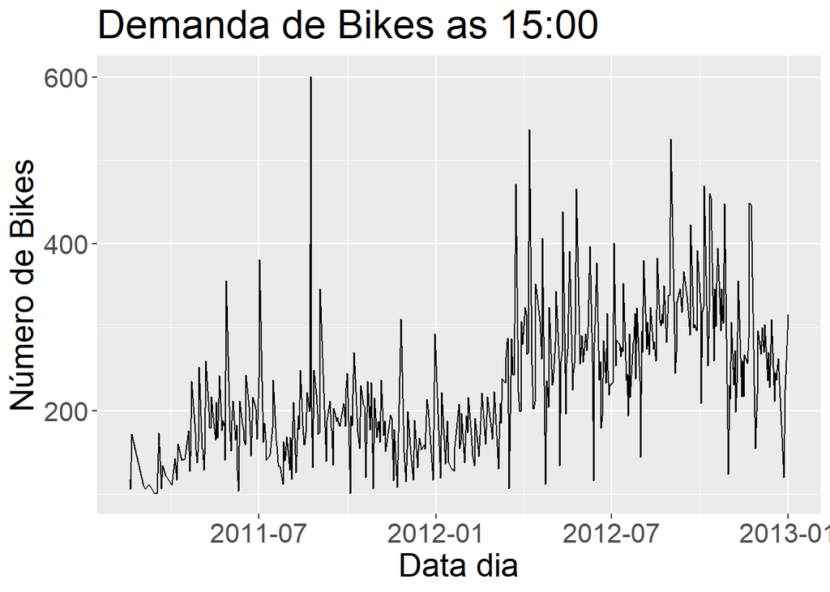

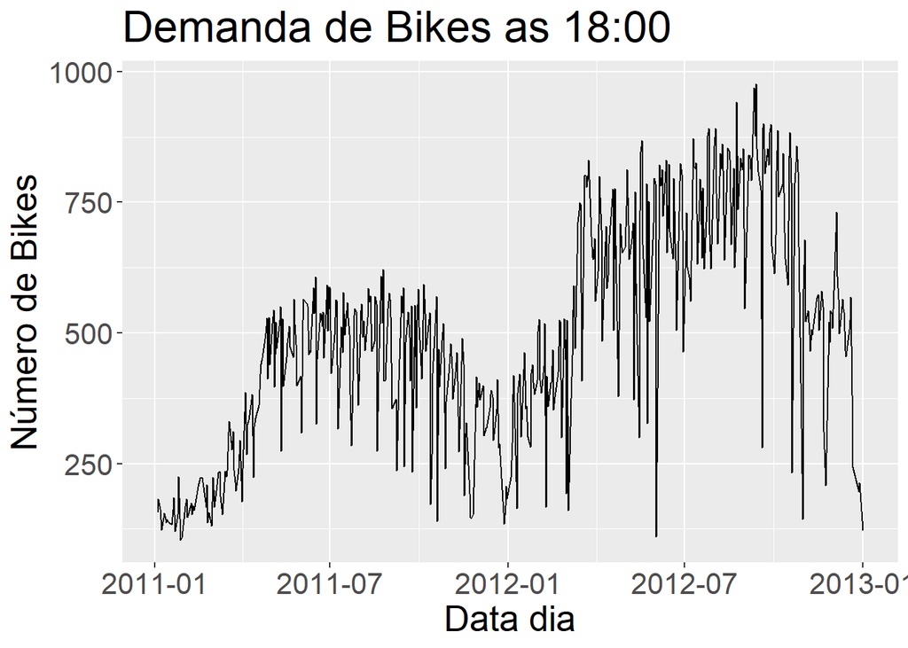

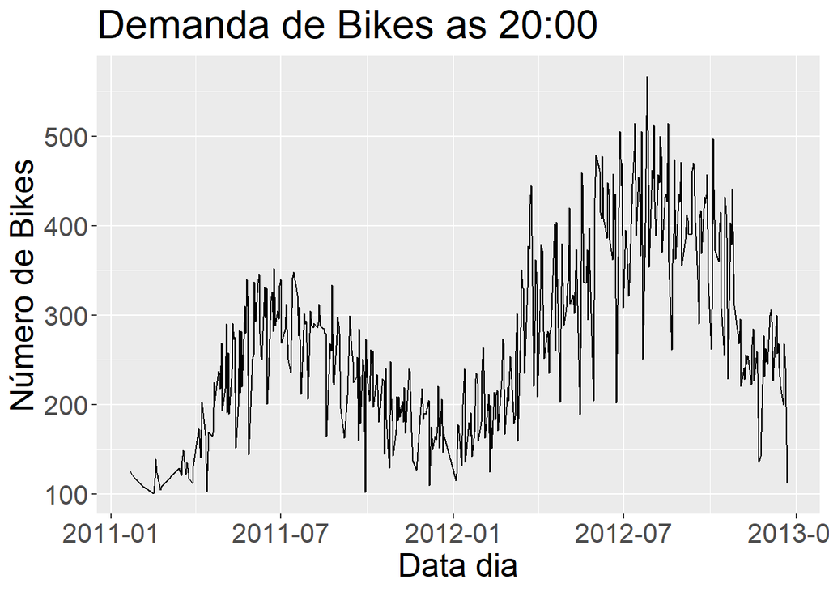

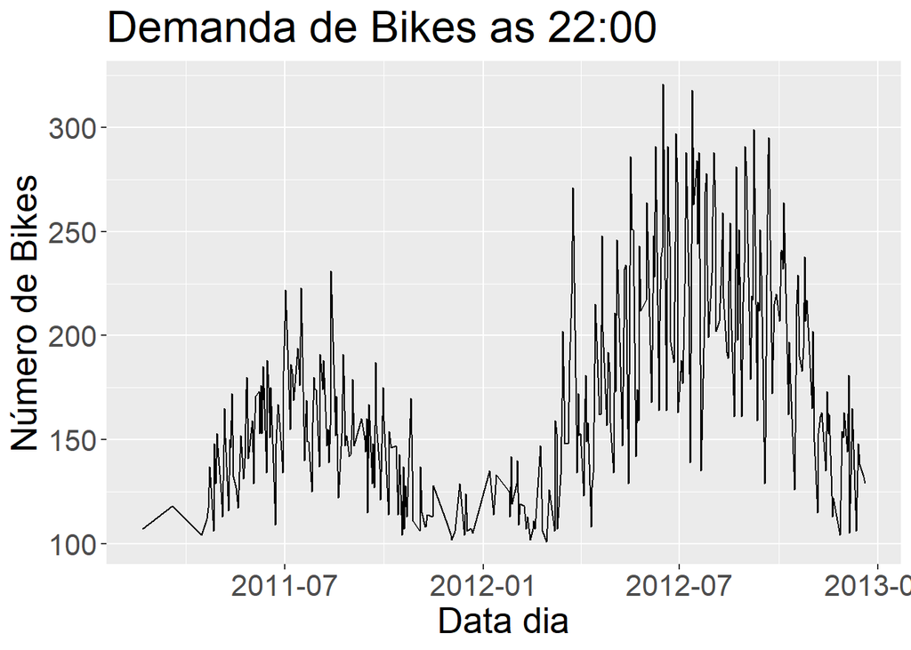

```r
library(ggplot2)

times <- c(7, 9, 12, 15, 18, 20, 22)


# Time Series Plot

tms.plot <- function(times){
  ggplot(bikes[bikes$workTime == times, ], aes(x = dteday, y = cnt)) +
    geom_line() +
    ylab('Número de Bikes') +
    xlab('Data dia') +
    labs(title = paste('Demanda de Bikes as ', as.character(times), ':00', sep =''))+
    theme(text = element_text(size = 20))
}

lapply(times, tms.plot)
```

## 5.1 Analisando BoxPlots

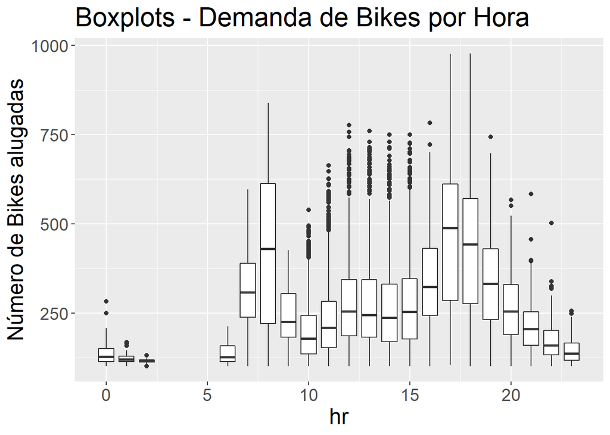

[figure not shown]

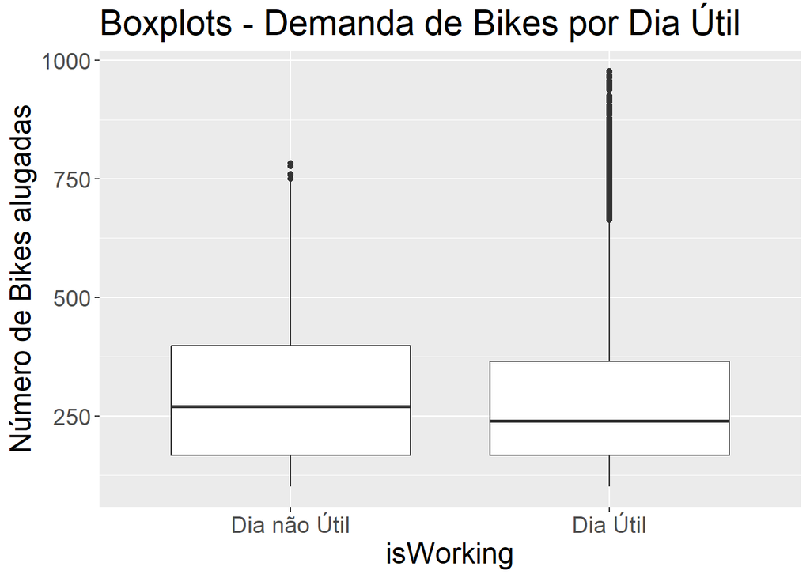

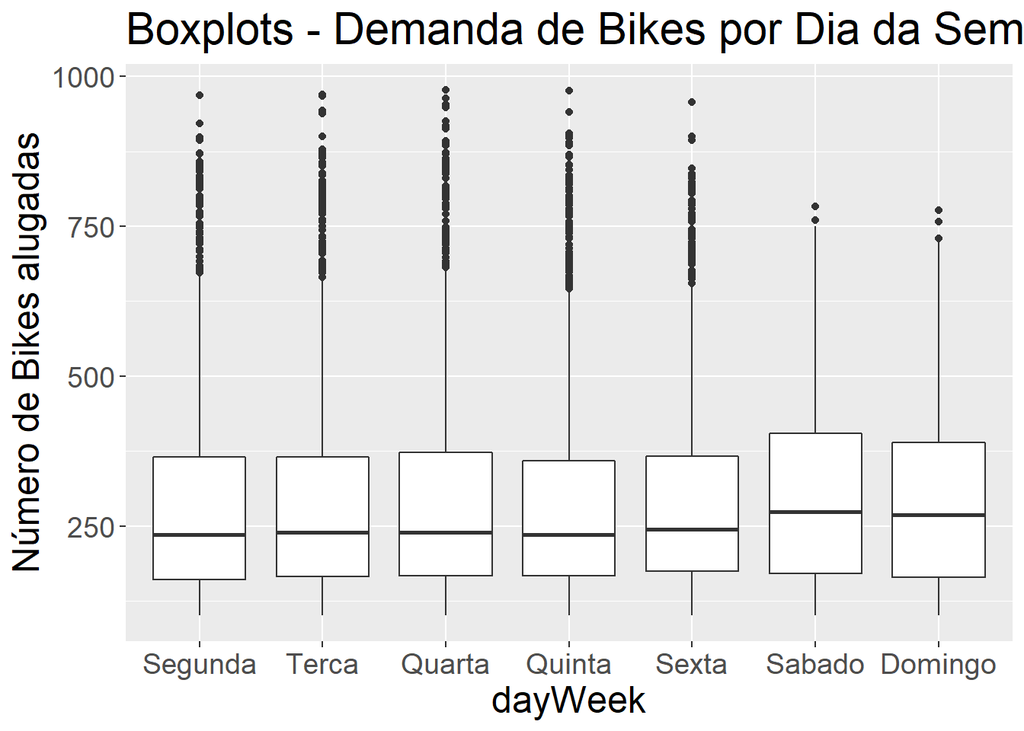

```r
# Convertendo a variável dayWeek para fator ordenado e plotando em ordem de tempo
fact.conv <- function(inVec){
  outVec <- as.factor(inVec)
  levels(outVec) <- c("Segunda", "Terca", "Quarta",
                      "Quinta", "Sexta", "Sabado",
                      "Domingo")
  outVec
}

bikes$dayWeek <- fact.conv(bikes$dayWeek)

# Convertendo a variável isWorking para fator ordenado e plotando em Dia não Útil e Dia Útil
fact.conv1 <- function(inVec){
  outVec1 <- as.factor(inVec)
  levels(outVec1) <- c("Dia não Útil", "Dia Útil")
  outVec1
}

bikes$isWorking <- fact.conv1(bikes$isWorking)


# Convertendo a variável isWorking para fator ordenado e plotando em Dia não Útil e Dia Útil
fact.conv2 <- function(inVec){
  outVec2 <- as.factor(inVec)
  levels(outVec2) <- c("Primavera", "Verão","Outuno", "Inverso")
  outVec2
}

bikes$weathersit <- fact.conv2(bikes$weathersit)

# Demanda de bikes x potenciais variáveis preditoras
labels <- list("Boxplots - Demanda de Bikes por Hora",
               "Boxplots - Demanda de Bikes por Estação",
               "Boxplots - Demanda de Bikes por Dia Útil",
               "Boxplots - Demanda de Bikes por Dia da Semana")

xAxis <- list("hr", "weathersit", "isWorking", "dayWeek")

# Função para criar os boxplots
plot.boxes  <- function(X, label){
  ggplot(bikes, aes_string(x = X, y = "cnt", group = X)) +
    ylab('Número de Bikes alugadas') +
    geom_boxplot( ) +
    ggtitle(label) +
    theme(text = element_text(size = 18))
}

Map(plot.boxes, xAxis, labels)
```

Visualizando o relacionamento entre as variáveis preditoras e demanda por bicicletas.

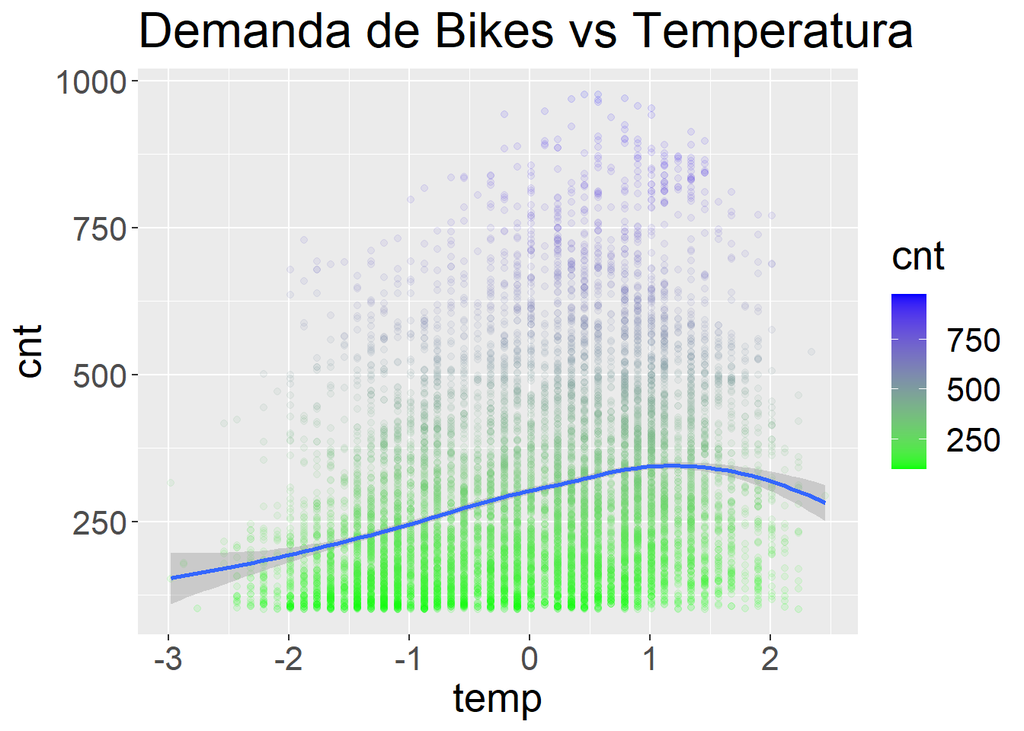

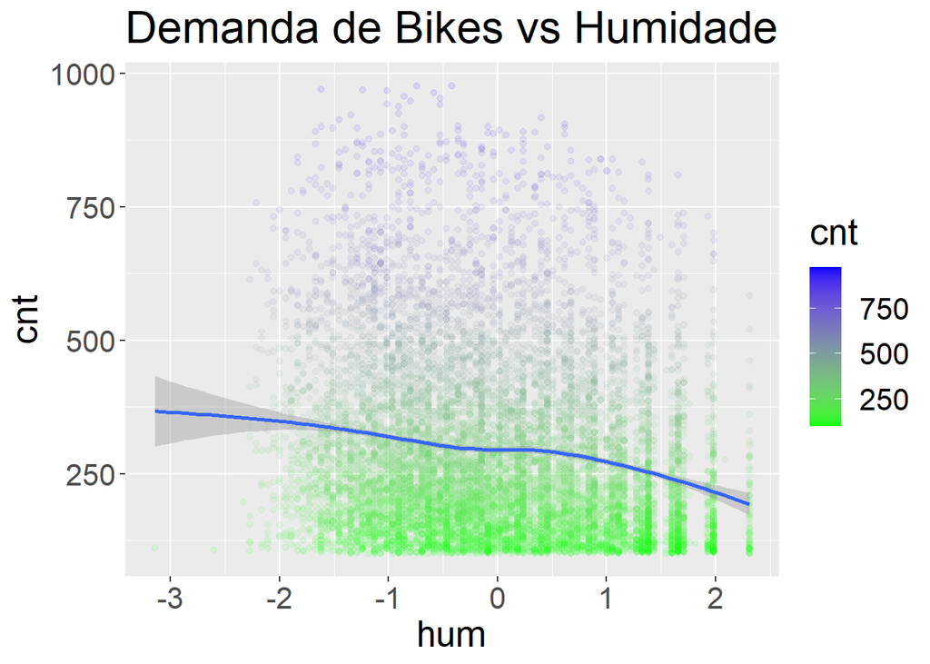

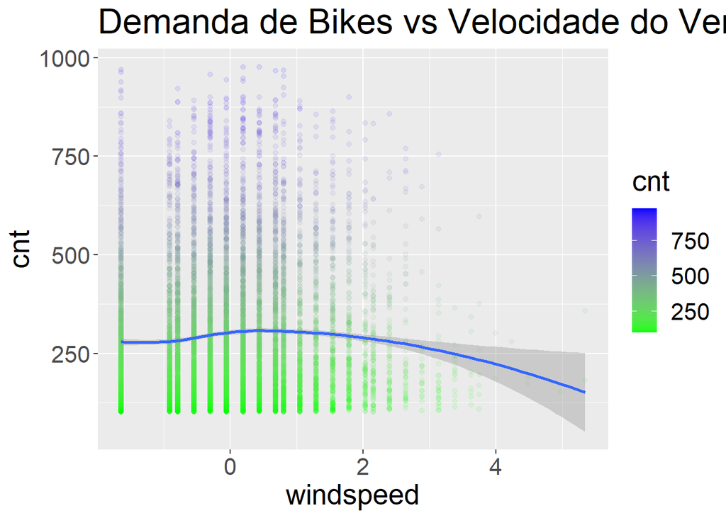

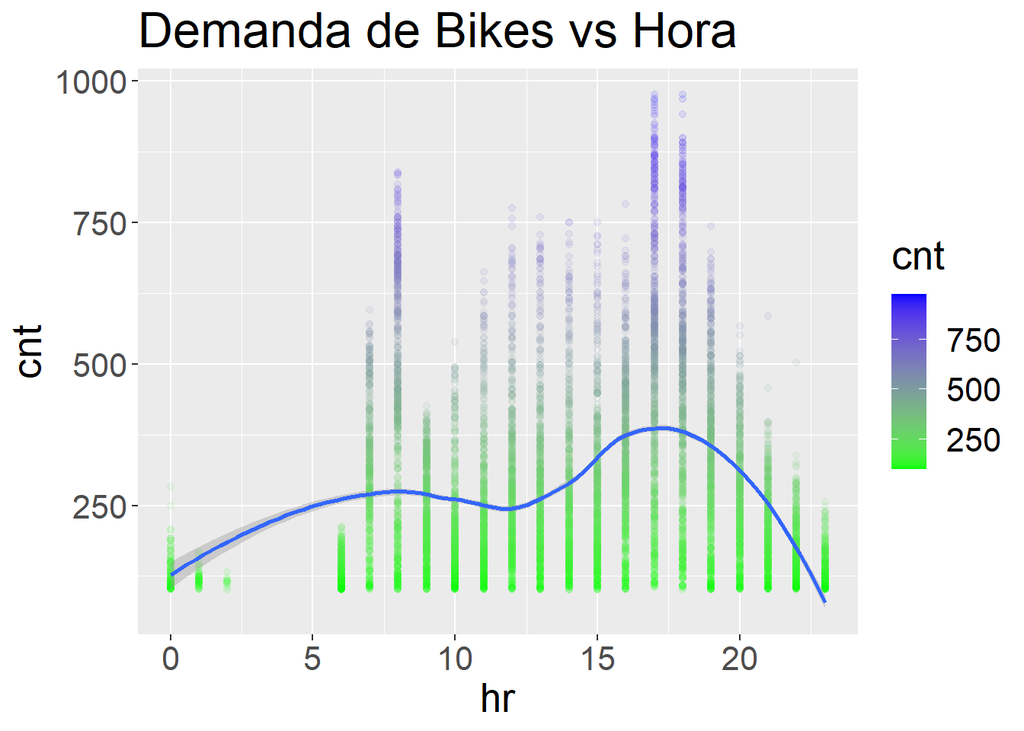

```r
labels <- c("Demanda de Bikes vs Temperatura",
            "Demanda de Bikes vs Humidade",
            "Demanda de Bikes vs Velocidade do Vento",
            "Demanda de Bikes vs Hora")

xAxis <- c("temp", "hum", "windspeed", "hr")

# Função para os Density Plots
plot.scatter <- function(X, label){
  ggplot(bikes, aes_string(x = X, y = "cnt")) +
    geom_point(aes_string(colour = "cnt"), alpha = 0.1) +
    scale_colour_gradient(low = "green", high = "blue") +
    geom_smooth(method = "loess") +
    ggtitle(label) +
    theme(text = element_text(size = 20))
}

Map(plot.scatter, xAxis, labels)
```

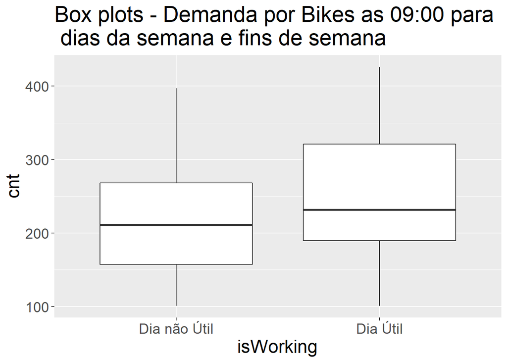

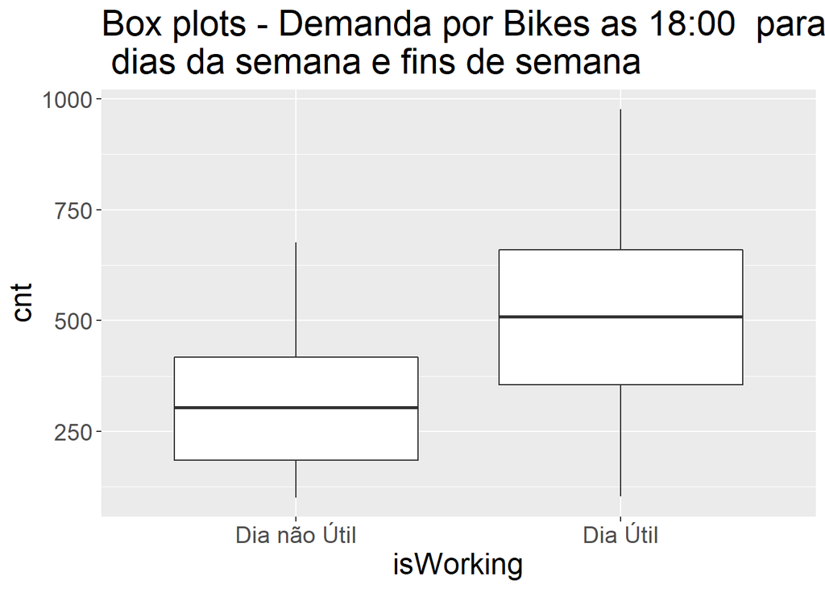

```r
# Explorando a interação entre tempo e dia, em dias da semana e fins de semana
labels <- list("Box plots - Demanda por Bikes as 09:00 para \n dias da semana e fins de semana",
               "Box plots - Demanda por Bikes as 18:00  para \n dias da semana e fins de semana")

Times <- list(9, 18)

plot.box2 <- function(time, label){
  ggplot(bikes[bikes$hr == time, ], aes(x = isWorking, y = cnt, group = isWorking)) +
    geom_boxplot( ) + ggtitle(label) +
    theme(text = element_text(size = 18)) }

Map(plot.box2, Times, labels)
```

# 6 Feature Selection

A seleção de Atributos, ou o Feature Selection tem como objetivo a simpleficação do modelo, para facilitar sua interpretação, dredução do tempo de treinamento do modelo e melhoria da generalização do modelo, evitando overfitting. Utilizaremos a tecnicas de feaure selection para automitizar a seleção de variáveis com maior potencial para variáveis preditoras. Sendo uma espécia de filtro, que remove do seu dataset as variáveis qwue não serão úteis para a criação do modelo preditivo. Tem como principal objetivo a criação de um modelo preditoco com a maior precisão possível e que seja generalizável. As técnicas de Feaure Selection basicamente calculam o nível de signifiância de cada variável e eliminam aquelas com significância mais baixa.

```r
dim(bikes)
```

```
## [1] 10342    16
```

```r
any()
```

```
## [1] FALSE
```

Criando um modelo para identificar os atributos com maior importância para o modelo preditivo

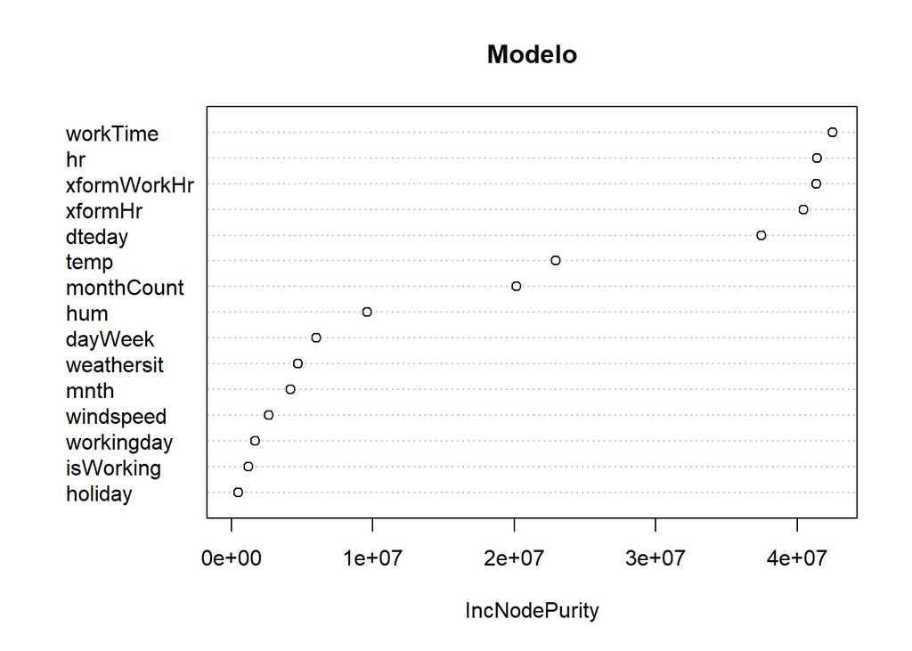

```r
library(randomForest)

Modelo <- randomForest(cnt ~.,
                       data = bikes,
                       ntree = 100,
                       nodesize = 10,
                       inportance = TRUE)

# Plotando as variáveis por grau de importância
varImpPlot(Modelo)
```

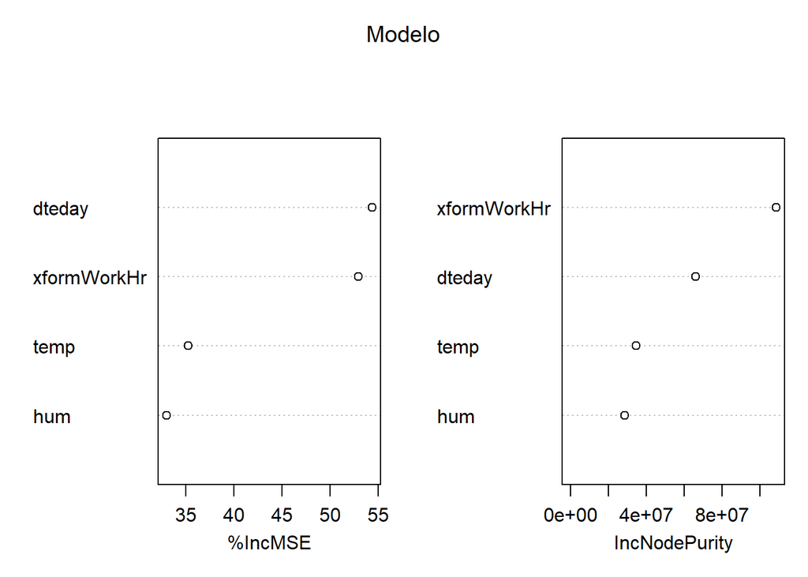

```r
# Removendo variáveis colineares
Modelo <- randomForest(cnt ~ . - mnth
                       - hr
                       - workingday
                       - isWorking
                       - dayWeek
                       - xformHr
                       - workTime
                       - holiday
                       - windspeed
                       - monthCount
                       - weathersit,
                       data = bikes,
                       ntree = 100,
                       nodesize = 10,
                       importance = TRUE)

# Removendo variáveis colineares
varImpPlot(Modelo)
```

# 7 Criando um modelo preditivo

```r
# Função para tratar as datas
set.asPOSIXct <- function(inFrame) {
  dteday <- as.POSIXct(
    as.integer(inFrame$dteday),
    origin = "1970-01-01")

  as.POSIXct(strptime(
    paste(as.character(dteday),
          " ",
          as.character(inFrame$hr),
          ":00:00",
          sep = ""),
    "%Y-%m-%d %H:%M:%S"))
}

char.toPOSIXct <-   function(inFrame) {
  as.POSIXct(strptime(
    paste(inFrame$dteday, " ",
          as.character(inFrame$hr),
          ":00:00",
          sep = ""),
    "%Y-%m-%d %H:%M:%S")) }
```

## 7.1 Treinamento o modelo

```r
 model <- randomForest(cnt ~ xformWorkHr + dteday + temp + hum,
                      data = bikes,
                      ntree = 40,
                      nodesize = 5)
print(model)
```

```
##
## Call:
##  randomForest(formula = cnt ~ xformWorkHr + dteday + temp + hum,      data = bikes, ntree = 40, nodesize = 5)
##                Type of random forest: regression
##                      Number of trees: 40
## No. of variables tried at each split: 1
##
##           Mean of squared residuals: 5421.007
##                     % Var explained: 80.39
```

```r
scores <- data.frame(actual = bikes$cnt,
                     prediction = predict(model, newdata = bikes))
```

## 7.2 Avaliando o modelo

```r
inFrame <- scores[, c("actual", "prediction")]
refFrame <- bikes

rbind(head(scores), tail(scores))
```

|  | actual | prediction |
| --- | --- | --- |
| 1 | 106 | 139.8357 |
| 2 | 110 | 147.7176 |
| 3 | 154 | 204.4852 |
| 4 | 157 | 172.3181 |
| 5 | 157 | 171.5598 |
| 6 | 110 | 121.6428 |
| 10339 | 247 | 246.3966 |
| 10340 | 315 | 257.0049 |
| 10341 | 214 | 208.4327 |
| 10342 | 164 | 183.8803 |

[output cut: 2 more lines]

```r
summary(scores)
```

```
##      actual        prediction
##  Min.   :101.0   Min.   :112.2
##  1st Qu.:167.0   1st Qu.:188.6
##  Median :246.0   Median :256.3
##  Mean   :294.1   Mean   :294.3
##  3rd Qu.:377.0   3rd Qu.:362.7
##  Max.   :977.0   Max.   :874.1
```

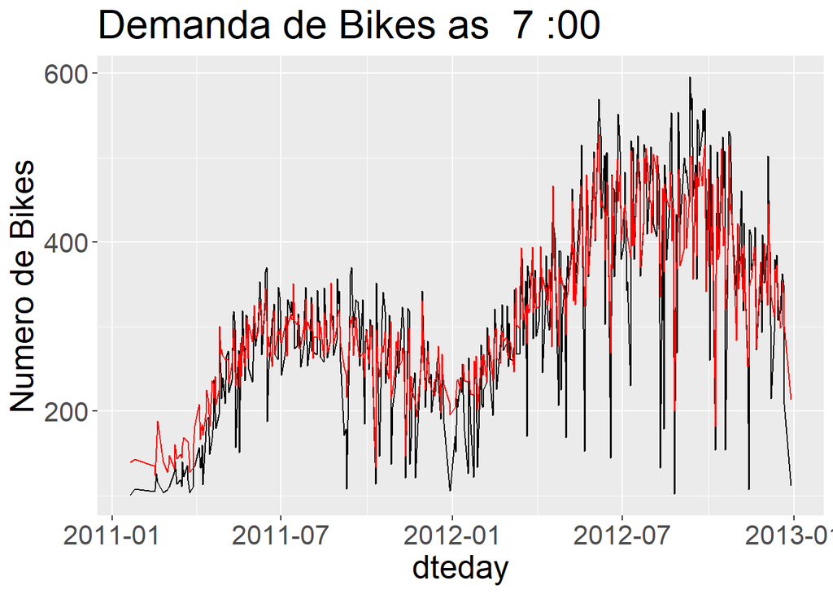

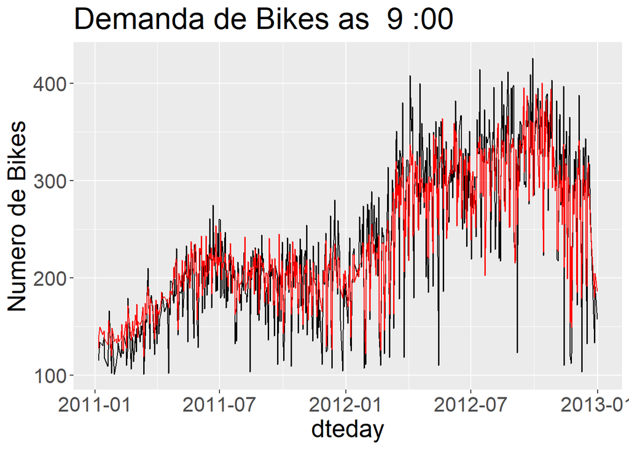

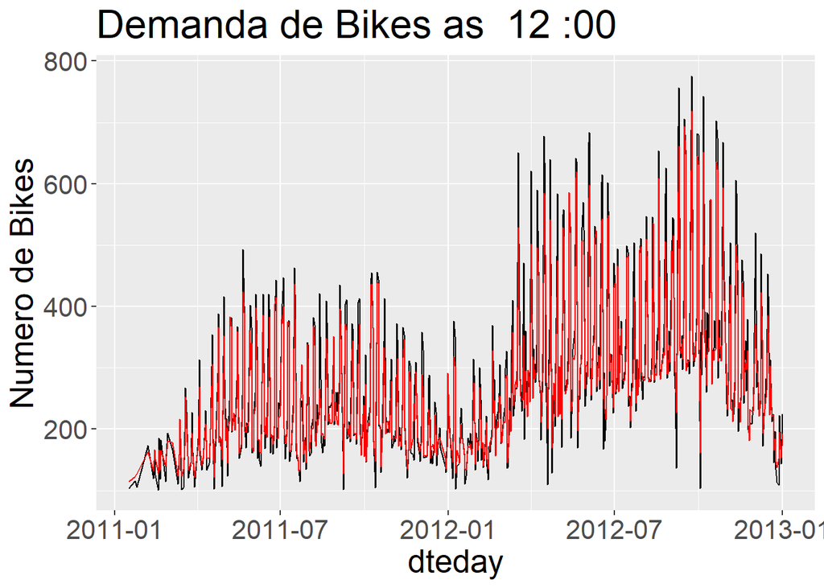

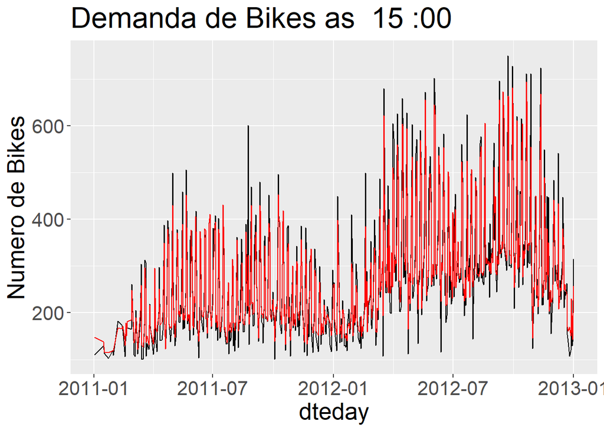

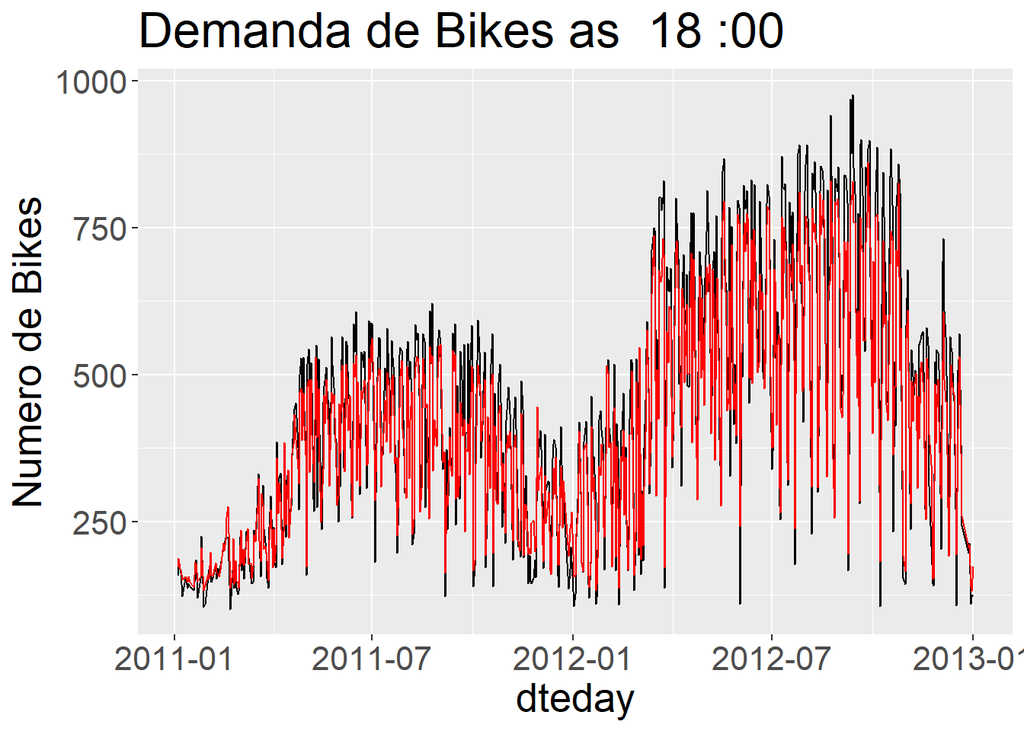

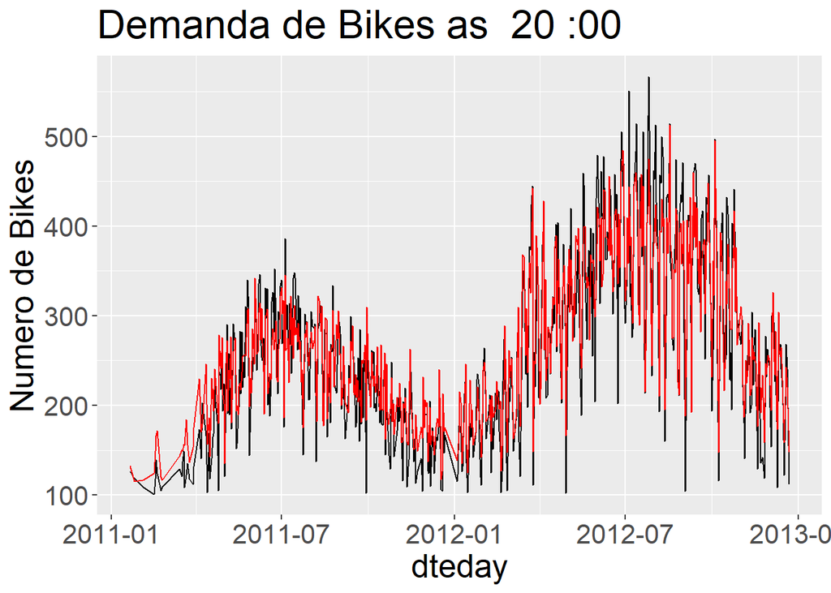

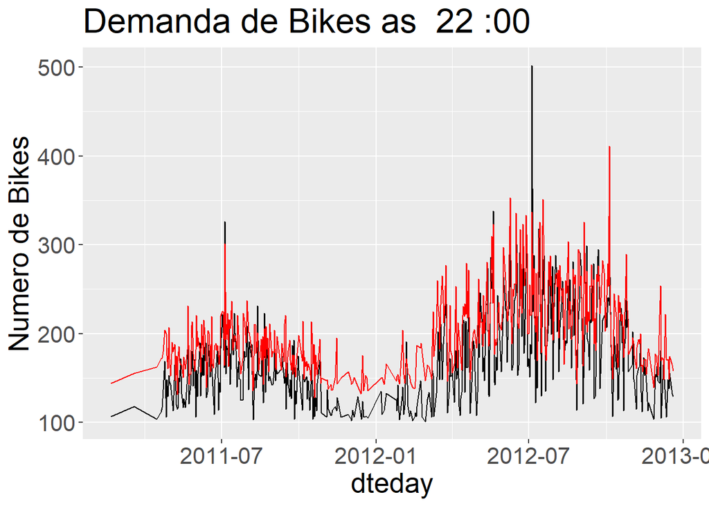

```r
# Criando um dataframe
inFrame[, c("dteday", "monthCount", "hr", "xformWorkHr")] <- refFrame[, c("dteday", "monthCount", "hr", "xformWorkHr")]

# Nomeando o dataframe
names(inFrame) <- c("cnt", "predicted", "dteday", "monthCount", "hr", "xformWorkHr")

#  Time series plot mostrando a diferença entre valores reais e valores previstos
inFrame <- inFrame[order(inFrame$dteday),]
s <- c(7, 9, 12, 15, 18, 20, 22)

lapply(s, function(s){
  ggplot() +
    geom_line(data = inFrame[inFrame$hr == s, ],
              aes(x = dteday, y = cnt)) +
    geom_line(data = inFrame[inFrame$hr == s, ],
              aes(x = dteday, y = predicted), color = "red") +
    ylab("Numero de Bikes") +
    labs(title = paste("Demanda de Bikes as ",
                       as.character(s), ":00", spe ="")) +
    theme(text = element_text(size = 20))
})
```

Conforme podemos observar a linha preta é exatamento os dados que temos nosso conjuto de dados original.

A linha vermelha demonstra as nossas previsões com o modelo.

## 7.3 Computando os resíduos

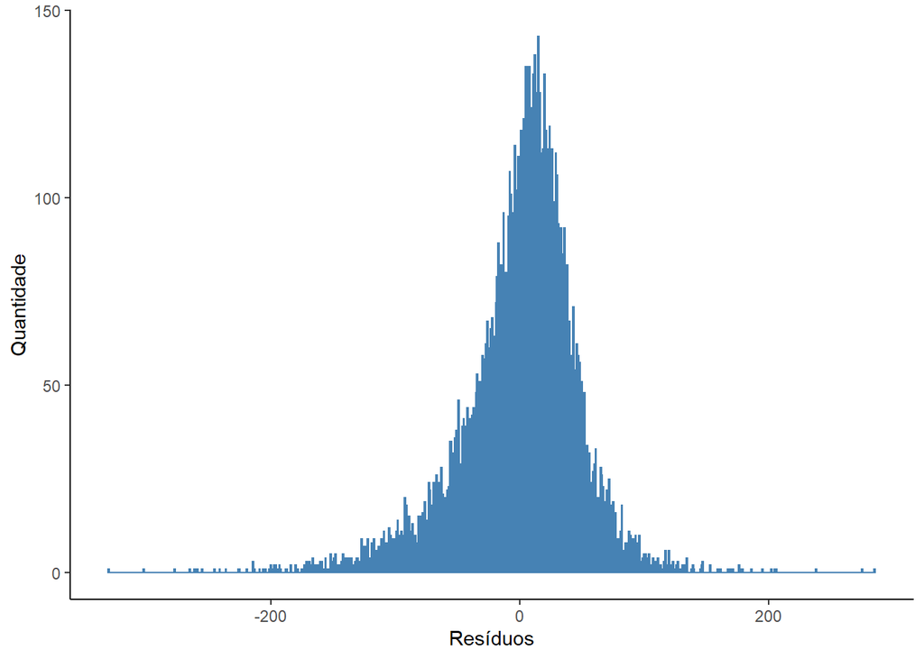

```r
inFrame <-  mutate(inFrame, resids = predicted - cnt)

# Plotando os resíduos
ggplot(inFrame, aes(x = resids)) +
  xlab('Resíduos') +
  ylab("Quantidade") +
  theme_classic() +
  geom_histogram(binwidth = 1, fill = "white", color = "steelblue")
```

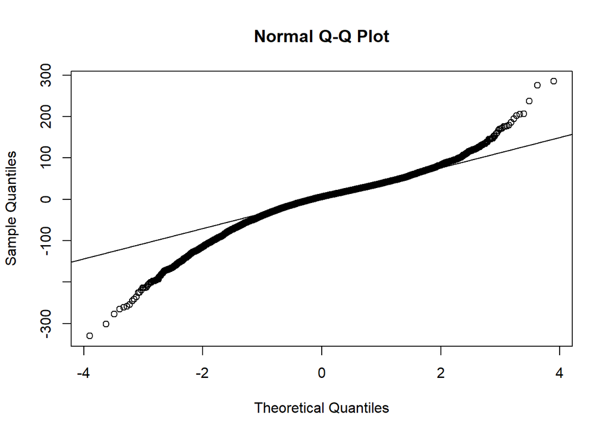

```r
# Distribuição os resíduos
qqnorm(inFrame$resids)
qqline(inFrame$resids)
```

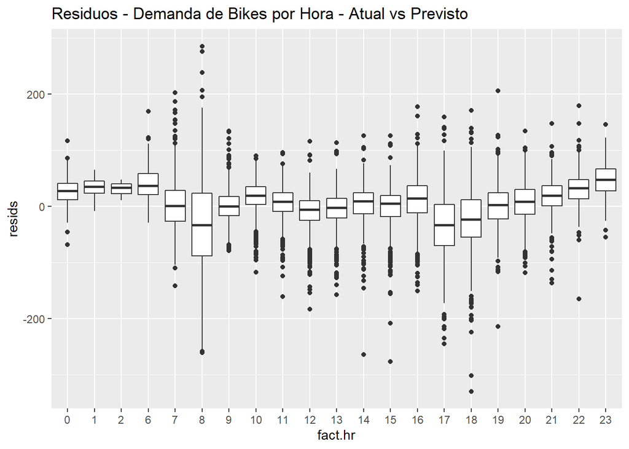

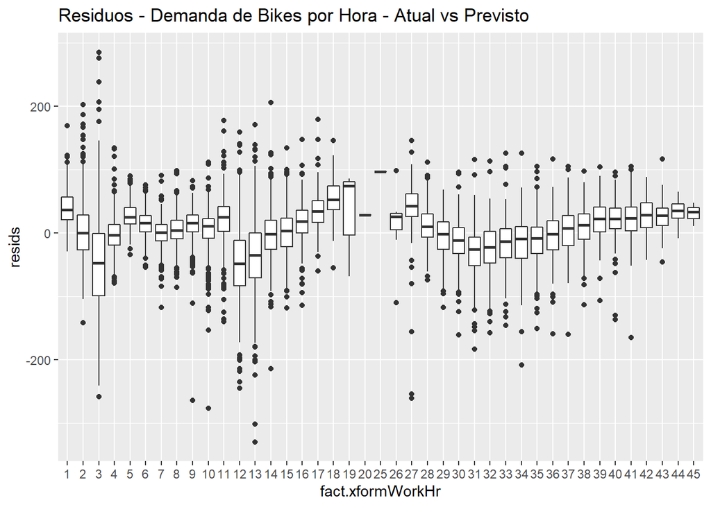

```r
# Plotando os resíduos com as horas transformadas
inFrame <- mutate(inFrame, fact.hr = as.factor(hr),
                  fact.xformWorkHr = as.factor(xformWorkHr))

facts <- c("fact.hr", "fact.xformWorkHr")

lapply(facts, function(x){
  ggplot(inFrame, aes_string(x = x, y = "resids"), fill = "steelblue") +
    geom_boxplot( ) +
    ggtitle("Residuos - Demanda de Bikes por Hora - Atual vs Previsto")})
```

```r
head(inFrame)
```

|  | cnt | predicted | dteday | monthCount | hr | xformWorkHr | resids | fact.hr | fact.xformWorkHr |
| --- | --- | --- | --- | --- | --- | --- | --- | --- | --- |
| 1 | 106 | 139.8357 | 2011-01-01 14:00:00 | 1 | 14 | 33 | 33.83574 | 14 | 33 |
| 2 | 110 | 147.7176 | 2011-01-01 15:00:00 | 1 | 15 | 34 | 37.71757 | 15 | 34 |
| 3 | 154 | 204.4852 | 2011-01-03 08:00:00 | 1 | 8 | 3 | 50.48518 | 8 | 3 |
| 4 | 157 | 172.3181 | 2011-01-03 17:00:00 | 1 | 17 | 12 | 15.31814 | 17 | 12 |
| 5 | 157 | 171.5598 | 2011-01-03 18:00:00 | 1 | 18 | 13 | 14.55976 | 18 | 13 |
| 6 | 110 | 121.6428 | 2011-01-03 19:00:00 | 1 | 19 | 14 | 11.64275 | 19 | 14 |

```r
# Mediana dos resíduos por hora
evalFrame <- inFrame %>%
  group_by(hr) %>%
  summarise(medResidByHr = format(round(
    median(predicted - cnt), 2),
    nsmall = 2))

# Computando a mediana dos resíduos
tempFrame <- inFrame %>%
  group_by(monthCount) %>%
  summarise(medResid = median(predicted - cnt))

summary(tempFrame)
```

```
##    monthCount       medResid
##  Min.   : 1.00   Min.   :-0.9845
##  1st Qu.: 6.75   1st Qu.: 4.5589
##  Median :12.50   Median : 6.0890
##  Mean   :12.50   Mean   : 6.2618
##  3rd Qu.:18.25   3rd Qu.: 8.2514
##  Max.   :24.00   Max.   :13.9239
```

```r
head(evalFrame)
```

| hr | medResidByHr |
| --- | --- |
| 0 | 27.30 |
| 1 | 34.57 |
| 2 | 32.84 |
| 6 | 36.64 |
| 7 | 0.45 |
| 8 | -33.74 |